[figure not shown]

# Python Bootcamp

### August 24-25, 2019, Seattle, WA

# Introduction to Pandas

`pandas` is a library with high-level data structures and manipulation tools:

- Data loading/saving
- Data exploration
- Filtering, selecting
- Plotting/visualization
- Computing summary statistics
- Groupby operations

**DataFrame Object**

- Represents a tabular, spreadsheet-like data structure
- Ordered collection of columns
- Each column can be a different value type (numeric, string, boolean, etc.)

This introduction will only just scratch the surface of Pandas functionality. For more information, check out the [full documentation](http://pandas.pydata.org/pandas-docs/stable/index.html).

Or check out the ['10 minutes to Pandas'](http://pandas.pydata.org/pandas-docs/stable/10min.html) tutorial here (note: title may mischaracterize time investment).

## Let's roll

```python
from IPython.display import HTML
HTML("""<iframe src="https://giphy.com/embed/QoCoLo2opwUW4" width="480" height="278" frameBorder="0" class="giphy-embed" allowFullScreen></iframe><p><a href="https://giphy.com/gifs/panda-playing-QoCoLo2opwUW4">via GIPHY</a></p>""")
```

[interactive chart not shown]

[via GIPHY](https://giphy.com/gifs/panda-playing-QoCoLo2opwUW4)

## Imports

```python
# Convention for import naming
import pandas as pd
```

```python
import numpy as np
import os
import matplotlib.pyplot as plt

%matplotlib inline
```

## Loading data

Pandas has a lot of convenient built-in methods for reading data of various formats.

Make and print a list of all of the Pandas methods with the word 'read' in them:

```python
read_methods = [x for x in dir(pd) if 'read' in x]
for method in read_methods:
    print(method)
```

```
read_clipboard
read_csv
read_excel
read_feather
read_fwf
read_gbq
read_hdf
read_html
read_json
read_msgpack
read_parquet
read_pickle
read_sas
read_sql
read_sql_query
read_sql_table
read_stata
read_table
```

## Load tabular data from CSV file

A simple csv file is saved in the working directory on your hard drive. We'll take a minute to open the file and view it.

Pandas can quickly load and display it. Note that it automatically parses the column names

```python
df = pd.read_csv(os.path.join('..', 'support_files', 'pokemon_alopez247.csv'))
```

## Use `head()` and `tail()` methods to take quick look at data structure

The `head()` method displays the first N rows, with N=5 by default

The `tail()` method displays the last N rows, with N=5 by default

```python
df.head()
```

|  | Number | Name | Type_1 | Type_2 | Total | HP | Attack | Defense | Sp_Atk | Sp_Def | ... | Color | hasGender | Pr_Male | Egg_Group_1 | Egg_Group_2 | hasMegaEvolution | Height_m | Weight_kg | Catch_Rate | Body_Style |
| --- | --- | --- | --- | --- | --- | --- | --- | --- | --- | --- | --- | --- | --- | --- | --- | --- | --- | --- | --- | --- | --- |
| 0 | 1 | Bulbasaur | Grass | Poison | 318 | 45 | 49 | 49 | 65 | 65 | ... | Green | True | 0.875 | Monster | Grass | False | 0.71 | 6.9 | 45 | quadruped |
| 1 | 2 | Ivysaur | Grass | Poison | 405 | 60 | 62 | 63 | 80 | 80 | ... | Green | True | 0.875 | Monster | Grass | False | 0.99 | 13.0 | 45 | quadruped |
| 2 | 3 | Venusaur | Grass | Poison | 525 | 80 | 82 | 83 | 100 | 100 | ... | Green | True | 0.875 | Monster | Grass | True | 2.01 | 100.0 | 45 | quadruped |
| 3 | 4 | Charmander | Fire | NaN | 309 | 39 | 52 | 43 | 60 | 50 | ... | Red | True | 0.875 | Monster | Dragon | False | 0.61 | 8.5 | 45 | bipedal_tailed |
| 4 | 5 | Charmeleon | Fire | NaN | 405 | 58 | 64 | 58 | 80 | 65 | ... | Red | True | 0.875 | Monster | Dragon | False | 1.09 | 19.0 | 45 | bipedal_tailed |

5 rows × 23 columns

```python
df.tail(2)
```

|  | Number | Name | Type_1 | Type_2 | Total | HP | Attack | Defense | Sp_Atk | Sp_Def | ... | Color | hasGender | Pr_Male | Egg_Group_1 | Egg_Group_2 | hasMegaEvolution | Height_m | Weight_kg | Catch_Rate | Body_Style |
| --- | --- | --- | --- | --- | --- | --- | --- | --- | --- | --- | --- | --- | --- | --- | --- | --- | --- | --- | --- | --- | --- |
| 719 | 720 | Hoopa | Psychic | Ghost | 600 | 80 | 110 | 60 | 150 | 130 | ... | Purple | False | NaN | Undiscovered | NaN | False | 0.51 | 9.0 | 3 | head_only |
| 720 | 721 | Volcanion | Fire | Water | 600 | 80 | 110 | 120 | 130 | 90 | ... | Brown | False | NaN | Undiscovered | NaN | False | 1.70 | 195.0 | 3 | quadruped |

2 rows × 23 columns

## Many familiar functions/methods work with DataFrames

```python
# numpy function
np.shape(df)
```

```
(721, 23)
```

```python
# python built-in function
len(df)
```

```
721
```

## This is because a DataFrame is "simply" a numpy array with columns and rows labelled

```python
# we can grab the underlying numpy array alone
df.values
```

```
array([[1, 'Bulbasaur', 'Grass', ..., 6.9, 45, 'quadruped'],
       [2, 'Ivysaur', 'Grass', ..., 13.0, 45, 'quadruped'],
       [3, 'Venusaur', 'Grass', ..., 100.0, 45, 'quadruped'],
       ...,
       [719, 'Diancie', 'Rock', ..., 8.8, 3, 'head_arms'],
       [720, 'Hoopa', 'Psychic', ..., 9.0, 3, 'head_only'],
       [721, 'Volcanion', 'Fire', ..., 195.0, 3, 'quadruped']],
      dtype=object)
```

```python
# we can also get the columns
df.columns
```

```
Index(['Number', 'Name', 'Type_1', 'Type_2', 'Total', 'HP', 'Attack',
       'Defense', 'Sp_Atk', 'Sp_Def', 'Speed', 'Generation', 'isLegendary',
       'Color', 'hasGender', 'Pr_Male', 'Egg_Group_1', 'Egg_Group_2',
       'hasMegaEvolution', 'Height_m', 'Weight_kg', 'Catch_Rate',
       'Body_Style'],
      dtype='object')
```

```python
# and the rows
df.index
```

```
RangeIndex(start=0, stop=721, step=1)
```

**Exercise 6.1:**

Identify another familiar function that works with the DataFrame

```python
type(df)
```

```
pandas.core.frame.DataFrame
```

## Selecting columns

Retrieve column based on column name.

There are two notations that allow you to access data from a column:

- bracket notation
- dot notation

Bracket notation:

```python
attack = df['Attack']
attack.head()
```

```
0    49
1    62
2    82
3    52
4    64
Name: Attack, dtype: int64
```

Dot notation:

note that this is sensitive to special characters in the variable name such as spaces, dashes, etc.

```python
body_style = df.Body_Style
print(body_style.head())
```

```
0         quadruped
1         quadruped
2         quadruped
3    bipedal_tailed
4    bipedal_tailed
Name: Body_Style, dtype: object
```

The returned column is a Series object

```python
print(type(body_style))
```

```
<class 'pandas.core.series.Series'>
```

**Exercise 6.3:**

1. What data type are entries in the column "Catch_Rate"?
2. What data type are entries in the column "Height_m"?

```python
print(df['Catch_Rate'].dtype)
print(df['Height_m'].dtype)
```

```
int64
float64
```

## The Series object has a lot of useful built-in functions

Start with `unique`

```python
df['Color'].unique()
```

```
array(['Green', 'Red', 'Blue', 'White', 'Brown', 'Yellow', 'Purple',
       'Pink', 'Grey', 'Black'], dtype=object)
```

```python
print("Pokemon types in this dataset:")
for line in df['Type_1'].unique():
    print("  ",line)
```

```
Pokemon types in this dataset:
   Grass
   Fire
   Water
   Bug
   Normal
   Poison
   Electric
   Ground
   Fairy
   Fighting
   Psychic
   Rock
   Ghost
   Ice
   Dragon
   Dark
   Steel
   Flying
```

**Exercise 6.2:**

1. How many different Egg Groups exist in this dataset?
2. How many different Body Styles exist in this dataset?

```python
len(df['Egg_Group_1'].unique())
```

```
15
```

```python
len(df['Body_Style'].unique())
```

```
14
```

## Get values as numpy ndarray

```python
weight = df['Weight_kg'].values
weight.shape
```

```
(721,)
```

Print the type of `weight`:

```python
print(type(weight))
```

```
<class 'numpy.ndarray'>
```

## Plot the weights using Matplotlib

We can use Matplotlib to plot the array that we just extracted from the dataframe:

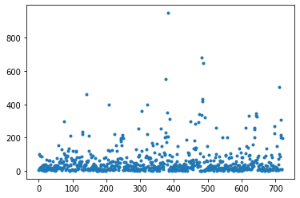

```python
# Plot array to inspect array
fig,ax = plt.subplots(1,1)
ax.plot(weight,'.')
```

## Plot the weights using Seaborn

Seaborn is a data visualization package that operates on Pandas dataframes, similar to the built-in plotting methods. It makes certain types of common visualizations very easy, including capturing multiple dimensions of data in the same plot. The results are still matplotlib axes objects, which you can use to update the title or other features. (Bonus exercise: can you make the marker color match the Color name in the example below? Try looking at the [scatterplot documentation](https://seaborn.pydata.org/generated/seaborn.scatterplot.html))

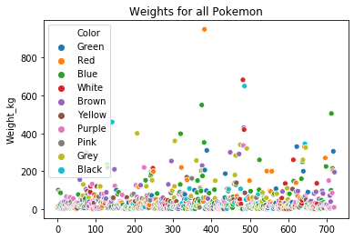

```python
import seaborn as sns

ax = sns.scatterplot(data=df, x=df.index, y='Weight_kg', hue='Color')

ax.set_title('Weights for all Pokemon')
```

**Exercise 6.4:**

Retrieve the heights and make plot of the relationship between weight and height. (Bonus: try out the seaborn regplot or jointplot functions - the arguments are specified just as in scatterplot)

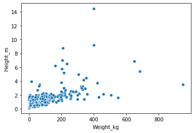

```python
sns.scatterplot(data=df, x='Weight_kg',y='Height_m')
```

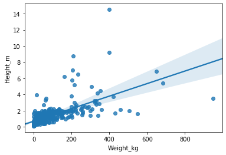

```python
sns.regplot(data=df, x='Weight_kg',y='Height_m')
```

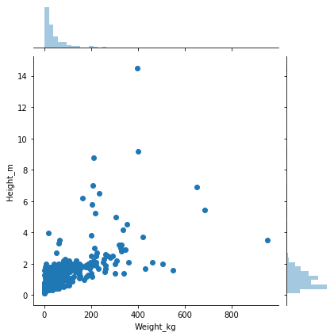

```python
sns.jointplot(data=df, x='Weight_kg',y='Height_m')
```

## Select multiple columns

We can make a new dataframe that contains only a subset of the column data from the first dataframe

```python
# Use copy to get new DataFrame object instead of a 'view' on existing object
df2 = df[['Type_1','Type_2','Weight_kg']].copy()
```

```python
df2.head(10)
```

|  | Type_1 | Type_2 | Weight_kg |
| --- | --- | --- | --- |
| 0 | Grass | Poison | 6.9 |
| 1 | Grass | Poison | 13.0 |
| 2 | Grass | Poison | 100.0 |
| 3 | Fire | NaN | 8.5 |
| 4 | Fire | NaN | 19.0 |
| 5 | Fire | Flying | 90.5 |
| 6 | Water | NaN | 9.0 |
| 7 | Water | NaN | 22.5 |
| 8 | Water | NaN | 85.5 |
| 9 | Bug | NaN | 2.9 |

## Adding, deleting columns

Let's add a column denoting whether the pokemon has a subtype.

Note that otherwise they have a `NaN` in the `Type_2` column

```python
df2['Type_2'].head()
```

```
0    Poison
1    Poison
2    Poison
3       NaN
4       NaN
Name: Type_2, dtype: object
```

Step 1:

We can use the `isnull` method to find all of the entries with `NaN` or `None`

```python
has_subtype = ~df2['Type_2'].isnull() #isnull() returns True if value is NaN or None.
print(has_subtype.head())
```

```
0     True
1     True
2     True
3    False
4    False
Name: Type_2, dtype: bool
```

Step 2:

We can create a new column and assign the `has_subtype` series that we just created to that column

```python
df2['has_subtype'] = has_subtype
```

```python
df2.head(5)
```

|  | Type_1 | Type_2 | Weight_kg | has_subtype |
| --- | --- | --- | --- | --- |
| 0 | Grass | Poison | 6.9 | True |
| 1 | Grass | Poison | 13.0 | True |
| 2 | Grass | Poison | 100.0 | True |
| 3 | Fire | NaN | 8.5 | False |
| 4 | Fire | NaN | 19.0 | False |

## Delete column (note: inplace argument)

```python
df2.drop('Type_2',axis=1,inplace=True)
# note: this would the same as df2 = df2.drop('Type_2',axis=1)
```

```python
df2.head(6)
```

|  | Type_1 | Weight_kg | has_subtype |
| --- | --- | --- | --- |
| 0 | Grass | 6.9 | True |
| 1 | Grass | 13.0 | True |
| 2 | Grass | 100.0 | True |
| 3 | Fire | 8.5 | False |
| 4 | Fire | 19.0 | False |
| 5 | Fire | 90.5 | True |

## Selecting rows and filtering

**Slice rows**

We can use Numpy-like slicing to access particular rows

```python
# this works...
df[150:190:10] # [start:end:step]
```

|  | Number | Name | Type_1 | Type_2 | Total | HP | Attack | Defense | Sp_Atk | Sp_Def | ... | Color | hasGender | Pr_Male | Egg_Group_1 | Egg_Group_2 | hasMegaEvolution | Height_m | Weight_kg | Catch_Rate | Body_Style |
| --- | --- | --- | --- | --- | --- | --- | --- | --- | --- | --- | --- | --- | --- | --- | --- | --- | --- | --- | --- | --- | --- |
| 150 | 151 | Mew | Psychic | NaN | 600 | 100 | 100 | 100 | 100 | 100 | ... | Pink | False | NaN | Undiscovered | NaN | False | 0.41 | 4.0 | 45 | bipedal_tailed |
| 160 | 161 | Sentret | Normal | NaN | 215 | 35 | 46 | 34 | 35 | 45 | ... | Brown | True | 0.5 | Field | NaN | False | 0.79 | 6.0 | 255 | quadruped |
| 170 | 171 | Lanturn | Water | Electric | 460 | 125 | 58 | 58 | 76 | 76 | ... | Blue | True | 0.5 | Water_2 | NaN | False | 1.19 | 22.5 | 75 | with_fins |
| 180 | 181 | Ampharos | Electric | NaN | 510 | 90 | 75 | 85 | 115 | 90 | ... | Yellow | True | 0.5 | Monster | Field | True | 1.40 | 61.5 | 45 | bipedal_tailed |

4 rows × 23 columns

```python
# but can be confusing since that's how we get columns. Better:
df.loc[150:190:10]
```

|  | Number | Name | Type_1 | Type_2 | Total | HP | Attack | Defense | Sp_Atk | Sp_Def | ... | Color | hasGender | Pr_Male | Egg_Group_1 | Egg_Group_2 | hasMegaEvolution | Height_m | Weight_kg | Catch_Rate | Body_Style |
| --- | --- | --- | --- | --- | --- | --- | --- | --- | --- | --- | --- | --- | --- | --- | --- | --- | --- | --- | --- | --- | --- |
| 150 | 151 | Mew | Psychic | NaN | 600 | 100 | 100 | 100 | 100 | 100 | ... | Pink | False | NaN | Undiscovered | NaN | False | 0.41 | 4.0 | 45 | bipedal_tailed |
| 160 | 161 | Sentret | Normal | NaN | 215 | 35 | 46 | 34 | 35 | 45 | ... | Brown | True | 0.5 | Field | NaN | False | 0.79 | 6.0 | 255 | quadruped |
| 170 | 171 | Lanturn | Water | Electric | 460 | 125 | 58 | 58 | 76 | 76 | ... | Blue | True | 0.5 | Water_2 | NaN | False | 1.19 | 22.5 | 75 | with_fins |
| 180 | 181 | Ampharos | Electric | NaN | 510 | 90 | 75 | 85 | 115 | 90 | ... | Yellow | True | 0.5 | Monster | Field | True | 1.40 | 61.5 | 45 | bipedal_tailed |
| 190 | 191 | Sunkern | Grass | NaN | 180 | 30 | 30 | 30 | 30 | 30 | ... | Yellow | True | 0.5 | Grass | NaN | False | 0.30 | 1.8 | 235 | head_only |

5 rows × 23 columns

```python
# indices are maintained when you create a series object from a column
df['Name'][150:190:10]
```

```
150         Mew
160     Sentret
170     Lanturn
180    Ampharos
Name: Name, dtype: object
```

```python
# the index can be any unique set of values. Let's make the index the name of the pokemon

df.set_index('Name',inplace=True)
```

```python
df.head()
```

| Name | Number | Type_1 | Type_2 | Total | HP | Attack | Defense | Sp_Atk | Sp_Def | Speed | ... | Color | hasGender | Pr_Male | Egg_Group_1 | Egg_Group_2 | hasMegaEvolution | Height_m | Weight_kg | Catch_Rate | Body_Style |
| --- | --- | --- | --- | --- | --- | --- | --- | --- | --- | --- | --- | --- | --- | --- | --- | --- | --- | --- | --- | --- | --- |
| Bulbasaur | 1 | Grass | Poison | 318 | 45 | 49 | 49 | 65 | 65 | 45 | ... | Green | True | 0.875 | Monster | Grass | False | 0.71 | 6.9 | 45 | quadruped |
| Ivysaur | 2 | Grass | Poison | 405 | 60 | 62 | 63 | 80 | 80 | 60 | ... | Green | True | 0.875 | Monster | Grass | False | 0.99 | 13.0 | 45 | quadruped |
| Venusaur | 3 | Grass | Poison | 525 | 80 | 82 | 83 | 100 | 100 | 80 | ... | Green | True | 0.875 | Monster | Grass | True | 2.01 | 100.0 | 45 | quadruped |
| Charmander | 4 | Fire | NaN | 309 | 39 | 52 | 43 | 60 | 50 | 65 | ... | Red | True | 0.875 | Monster | Dragon | False | 0.61 | 8.5 | 45 | bipedal_tailed |
| Charmeleon | 5 | Fire | NaN | 405 | 58 | 64 | 58 | 80 | 65 | 80 | ... | Red | True | 0.875 | Monster | Dragon | False | 1.09 | 19.0 | 45 | bipedal_tailed |

5 rows × 22 columns

```python
# Now this breaks because our indices are no longer integers
try:
    df.loc[150:190:10]
except Exception as e:
    print(e)
```

```
cannot do slice indexing on <class 'pandas.core.indexes.base.Index'> with these indexers [150] of <class 'int'>
```

```python
# instead, we can use .loc to grab rows just like we grab columns
df.loc[['Bulbasaur','Ivysaur','Charmander']]
```

| Name | Number | Type_1 | Type_2 | Total | HP | Attack | Defense | Sp_Atk | Sp_Def | Speed | ... | Color | hasGender | Pr_Male | Egg_Group_1 | Egg_Group_2 | hasMegaEvolution | Height_m | Weight_kg | Catch_Rate | Body_Style |
| --- | --- | --- | --- | --- | --- | --- | --- | --- | --- | --- | --- | --- | --- | --- | --- | --- | --- | --- | --- | --- | --- |
| Bulbasaur | 1 | Grass | Poison | 318 | 45 | 49 | 49 | 65 | 65 | 45 | ... | Green | True | 0.875 | Monster | Grass | False | 0.71 | 6.9 | 45 | quadruped |
| Ivysaur | 2 | Grass | Poison | 405 | 60 | 62 | 63 | 80 | 80 | 60 | ... | Green | True | 0.875 | Monster | Grass | False | 0.99 | 13.0 | 45 | quadruped |
| Charmander | 4 | Fire | NaN | 309 | 39 | 52 | 43 | 60 | 50 | 65 | ... | Red | True | 0.875 | Monster | Dragon | False | 0.61 | 8.5 | 45 | bipedal_tailed |

3 rows × 22 columns

**Select rows based on boolean array (very commonly used)**

This is very powerful as it lets you slice the dataframe using logical conditions

```python
df.head()
```

| Name | Number | Type_1 | Type_2 | Total | HP | Attack | Defense | Sp_Atk | Sp_Def | Speed | ... | Color | hasGender | Pr_Male | Egg_Group_1 | Egg_Group_2 | hasMegaEvolution | Height_m | Weight_kg | Catch_Rate | Body_Style |
| --- | --- | --- | --- | --- | --- | --- | --- | --- | --- | --- | --- | --- | --- | --- | --- | --- | --- | --- | --- | --- | --- |
| Bulbasaur | 1 | Grass | Poison | 318 | 45 | 49 | 49 | 65 | 65 | 45 | ... | Green | True | 0.875 | Monster | Grass | False | 0.71 | 6.9 | 45 | quadruped |
| Ivysaur | 2 | Grass | Poison | 405 | 60 | 62 | 63 | 80 | 80 | 60 | ... | Green | True | 0.875 | Monster | Grass | False | 0.99 | 13.0 | 45 | quadruped |
| Venusaur | 3 | Grass | Poison | 525 | 80 | 82 | 83 | 100 | 100 | 80 | ... | Green | True | 0.875 | Monster | Grass | True | 2.01 | 100.0 | 45 | quadruped |
| Charmander | 4 | Fire | NaN | 309 | 39 | 52 | 43 | 60 | 50 | 65 | ... | Red | True | 0.875 | Monster | Dragon | False | 0.61 | 8.5 | 45 | bipedal_tailed |
| Charmeleon | 5 | Fire | NaN | 405 | 58 | 64 | 58 | 80 | 65 | 80 | ... | Red | True | 0.875 | Monster | Dragon | False | 1.09 | 19.0 | 45 | bipedal_tailed |

5 rows × 22 columns

We can create a boolean array based on our `has_gender` column

```python
has_gender = df['hasGender']
print(has_gender.mean())
```

```
0.8932038834951457
```

And if we apply that boolean array to the entire dataframe, we'll be left with only rows where the boolean array was `True`

```python
df[has_gender].head(15)
```

| Name | Number | Type_1 | Type_2 | Total | HP | Attack | Defense | Sp_Atk | Sp_Def | Speed | ... | Color | hasGender | Pr_Male | Egg_Group_1 | Egg_Group_2 | hasMegaEvolution | Height_m | Weight_kg | Catch_Rate | Body_Style |
| --- | --- | --- | --- | --- | --- | --- | --- | --- | --- | --- | --- | --- | --- | --- | --- | --- | --- | --- | --- | --- | --- |
| Bulbasaur | 1 | Grass | Poison | 318 | 45 | 49 | 49 | 65 | 65 | 45 | ... | Green | True | 0.875 | Monster | Grass | False | 0.71 | 6.9 | 45 | quadruped |
| Ivysaur | 2 | Grass | Poison | 405 | 60 | 62 | 63 | 80 | 80 | 60 | ... | Green | True | 0.875 | Monster | Grass | False | 0.99 | 13.0 | 45 | quadruped |
| Venusaur | 3 | Grass | Poison | 525 | 80 | 82 | 83 | 100 | 100 | 80 | ... | Green | True | 0.875 | Monster | Grass | True | 2.01 | 100.0 | 45 | quadruped |
| Charmander | 4 | Fire | NaN | 309 | 39 | 52 | 43 | 60 | 50 | 65 | ... | Red | True | 0.875 | Monster | Dragon | False | 0.61 | 8.5 | 45 | bipedal_tailed |
| Charmeleon | 5 | Fire | NaN | 405 | 58 | 64 | 58 | 80 | 65 | 80 | ... | Red | True | 0.875 | Monster | Dragon | False | 1.09 | 19.0 | 45 | bipedal_tailed |
| Charizard | 6 | Fire | Flying | 534 | 78 | 84 | 78 | 109 | 85 | 100 | ... | Red | True | 0.875 | Monster | Dragon | True | 1.70 | 90.5 | 45 | bipedal_tailed |
| Squirtle | 7 | Water | NaN | 314 | 44 | 48 | 65 | 50 | 64 | 43 | ... | Blue | True | 0.875 | Monster | Water_1 | False | 0.51 | 9.0 | 45 | bipedal_tailed |
| Wartortle | 8 | Water | NaN | 405 | 59 | 63 | 80 | 65 | 80 | 58 | ... | Blue | True | 0.875 | Monster | Water_1 | False | 0.99 | 22.5 | 45 | bipedal_tailed |
| Blastoise | 9 | Water | NaN | 530 | 79 | 83 | 100 | 85 | 105 | 78 | ... | Blue | True | 0.875 | Monster | Water_1 | True | 1.60 | 85.5 | 45 | bipedal_tailed |
| Caterpie | 10 | Bug | NaN | 195 | 45 | 30 | 35 | 20 | 20 | 45 | ... | Green | True | 0.500 | Bug | NaN | False | 0.30 | 2.9 | 255 | insectoid |
| Metapod | 11 | Bug | NaN | 205 | 50 | 20 | 55 | 25 | 25 | 30 | ... | Green | True | 0.500 | Bug | NaN | False | 0.71 | 9.9 | 120 | serpentine_body |
| Butterfree | 12 | Bug | Flying | 395 | 60 | 45 | 50 | 90 | 80 | 70 | ... | White | True | 0.500 | Bug | NaN | False | 1.09 | 32.0 | 45 | four_wings |
| Weedle | 13 | Bug | Poison | 195 | 40 | 35 | 30 | 20 | 20 | 50 | ... | Brown | True | 0.500 | Bug | NaN | False | 0.30 | 3.2 | 255 | serpentine_body |
| Kakuna | 14 | Bug | Poison | 205 | 45 | 25 | 50 | 25 | 25 | 35 | ... | Yellow | True | 0.500 | Bug | NaN | False | 0.61 | 10.0 | 120 | serpentine_body |
| Beedrill | 15 | Bug | Poison | 395 | 65 | 90 | 40 | 45 | 80 | 75 | ... | Yellow | True | 0.500 | Bug | NaN | True | 0.99 | 29.5 | 45 | four_wings |

15 rows × 22 columns

**Expression in brackets that yields boolean array**

This can be done in one line by putting an expression into the brackets that will yield a boolean array

```python
df[df['hasGender']==False].head(5)
```

| Name | Number | Type_1 | Type_2 | Total | HP | Attack | Defense | Sp_Atk | Sp_Def | Speed | ... | Color | hasGender | Pr_Male | Egg_Group_1 | Egg_Group_2 | hasMegaEvolution | Height_m | Weight_kg | Catch_Rate | Body_Style |
| --- | --- | --- | --- | --- | --- | --- | --- | --- | --- | --- | --- | --- | --- | --- | --- | --- | --- | --- | --- | --- | --- |
| Magnemite | 81 | Electric | Steel | 325 | 25 | 35 | 70 | 95 | 55 | 45 | ... | Grey | False | NaN | Mineral | NaN | False | 0.30 | 6.0 | 190 | head_arms |
| Magneton | 82 | Electric | Steel | 465 | 50 | 60 | 95 | 120 | 70 | 70 | ... | Grey | False | NaN | Mineral | NaN | False | 0.99 | 60.0 | 60 | multiple_bodies |
| Voltorb | 100 | Electric | NaN | 330 | 40 | 30 | 50 | 55 | 55 | 100 | ... | Red | False | NaN | Mineral | NaN | False | 0.51 | 10.4 | 190 | head_only |
| Electrode | 101 | Electric | NaN | 480 | 60 | 50 | 70 | 80 | 80 | 140 | ... | Red | False | NaN | Mineral | NaN | False | 1.19 | 66.6 | 60 | head_only |
| Staryu | 120 | Water | NaN | 340 | 30 | 45 | 55 | 70 | 55 | 85 | ... | Brown | False | NaN | Water_3 | NaN | False | 0.79 | 34.5 | 225 | head_base |

5 rows × 22 columns

We can combine multiple logical statements using the `&` or `|` characters

For instance, let's find all of the non-gendered quadruped pokemon in our full dataframe:

```python
df['Body_Style'].value_counts()
```

```
bipedal_tailed      158
quadruped           135
bipedal_tailless    109
two_wings            63
head_arms            39
head_only            34
with_fins            31
insectoid            30
head_base            30
serpentine_body      29
four_wings           18
head_legs            17
multiple_bodies      15
several_limbs        13
Name: Body_Style, dtype: int64
```

```python
boolean_mask = (
    (df['hasGender']==False)
    & (df['Body_Style']=='quadruped')
)
df[boolean_mask]
```

| Name | Number | Type_1 | Type_2 | Total | HP | Attack | Defense | Sp_Atk | Sp_Def | Speed | ... | Color | hasGender | Pr_Male | Egg_Group_1 | Egg_Group_2 | hasMegaEvolution | Height_m | Weight_kg | Catch_Rate | Body_Style |
| --- | --- | --- | --- | --- | --- | --- | --- | --- | --- | --- | --- | --- | --- | --- | --- | --- | --- | --- | --- | --- | --- |
| Raikou | 243 | Electric | NaN | 580 | 90 | 85 | 75 | 115 | 100 | 115 | ... | Yellow | False | NaN | Undiscovered | NaN | False | 1.91 | 178.0 | 3 | quadruped |
| Entei | 244 | Fire | NaN | 580 | 115 | 115 | 85 | 90 | 75 | 100 | ... | Brown | False | NaN | Undiscovered | NaN | False | 2.11 | 198.0 | 3 | quadruped |
| Suicune | 245 | Water | NaN | 580 | 100 | 75 | 115 | 90 | 115 | 85 | ... | Blue | False | NaN | Undiscovered | NaN | False | 2.01 | 187.0 | 3 | quadruped |
| Dialga | 483 | Steel | Dragon | 680 | 100 | 120 | 120 | 150 | 100 | 90 | ... | White | False | NaN | Undiscovered | NaN | False | 5.41 | 683.0 | 3 | quadruped |
| Shaymin | 492 | Grass | NaN | 600 | 100 | 100 | 100 | 100 | 100 | 100 | ... | Green | False | NaN | Undiscovered | NaN | False | 0.20 | 2.1 | 45 | quadruped |
| Arceus | 493 | Normal | NaN | 720 | 120 | 120 | 120 | 120 | 120 | 120 | ... | Grey | False | NaN | Undiscovered | NaN | False | 3.20 | 320.0 | 3 | quadruped |
| Cobalion | 638 | Steel | Fighting | 580 | 91 | 90 | 129 | 90 | 72 | 108 | ... | Blue | False | NaN | Undiscovered | NaN | False | 2.11 | 250.0 | 3 | quadruped |
| Terrakion | 639 | Rock | Fighting | 580 | 91 | 129 | 90 | 72 | 90 | 108 | ... | Grey | False | NaN | Undiscovered | NaN | False | 1.91 | 260.0 | 3 | quadruped |
| Virizion | 640 | Grass | Fighting | 580 | 91 | 90 | 72 | 90 | 129 | 108 | ... | Green | False | NaN | Undiscovered | NaN | False | 2.01 | 200.0 | 3 | quadruped |
| Keldeo | 647 | Water | Fighting | 580 | 91 | 72 | 90 | 129 | 90 | 108 | ... | Yellow | False | NaN | Undiscovered | NaN | False | 1.40 | 48.5 | 3 | quadruped |
| Xerneas | 716 | Fairy | NaN | 680 | 126 | 131 | 95 | 131 | 98 | 99 | ... | Blue | False | NaN | Undiscovered | NaN | False | 3.00 | 215.0 | 45 | quadruped |
| Volcanion | 721 | Fire | Water | 600 | 80 | 110 | 120 | 130 | 90 | 70 | ... | Brown | False | NaN | Undiscovered | NaN | False | 1.70 | 195.0 | 3 | quadruped |

12 rows × 22 columns

**Exercise 6.5:**

1. Generate a new dataframe with only pokemon who can fly.
2. How fast are flying pokemon?

```python
flyers_mask = df['Body_Style'].str.contains('wings')

flyers = df[flyers_mask]
flyers['Speed'].describe()
```

```
count     81.000000
mean      82.740741
std       22.721563
min       40.000000
25%       65.000000
50%       80.000000
75%       97.000000
max      160.000000
Name: Speed, dtype: float64
```

## More useful methods

`isin()`

Use `isin()` to find all pokemon that are either Pink or Purple

```python
color_list = ['Purple','Pink']
purple_and_pink = df[df['Color'].isin(color_list)] #This is an alternative to using OR

print(
    'There are {} {} pokemon'.format(
        len(purple_and_pink),
        ' & '.join(color_list)
    )
)
```

```
There are 106 Purple & Pink pokemon
```

```python
purple_and_pink.head(6)
```

| Name | Number | Type_1 | Type_2 | Total | HP | Attack | Defense | Sp_Atk | Sp_Def | Speed | ... | Color | hasGender | Pr_Male | Egg_Group_1 | Egg_Group_2 | hasMegaEvolution | Height_m | Weight_kg | Catch_Rate | Body_Style |
| --- | --- | --- | --- | --- | --- | --- | --- | --- | --- | --- | --- | --- | --- | --- | --- | --- | --- | --- | --- | --- | --- |
| Rattata | 19 | Normal | NaN | 253 | 30 | 56 | 35 | 25 | 35 | 72 | ... | Purple | True | 0.5 | Field | NaN | False | 0.30 | 3.5 | 255 | quadruped |
| Ekans | 23 | Poison | NaN | 288 | 35 | 60 | 44 | 40 | 54 | 55 | ... | Purple | True | 0.5 | Field | Dragon | False | 2.01 | 6.9 | 255 | serpentine_body |
| Arbok | 24 | Poison | NaN | 438 | 60 | 85 | 69 | 65 | 79 | 80 | ... | Purple | True | 0.5 | Field | Dragon | False | 3.51 | 65.0 | 90 | serpentine_body |
| Nidoran♂ | 32 | Poison | NaN | 273 | 46 | 57 | 40 | 40 | 40 | 50 | ... | Purple | True | 1.0 | Monster | Field | False | 0.51 | 9.0 | 235 | quadruped |
| Nidorino | 33 | Poison | NaN | 365 | 61 | 72 | 57 | 55 | 55 | 65 | ... | Purple | True | 1.0 | Monster | Field | False | 0.89 | 19.5 | 120 | quadruped |
| Nidoking | 34 | Poison | Ground | 505 | 81 | 102 | 77 | 85 | 75 | 85 | ... | Purple | True | 1.0 | Monster | Field | False | 1.40 | 62.0 | 45 | bipedal_tailed |

6 rows × 22 columns

`value_counts()`

This method returns an object containing counts of unique values, in descending order.

```python
# Top 20 Cre lines used in connectivity atlas
df['Color'].value_counts()
```

```
Blue      134
Brown     110
Green      79
Red        75
Grey       69
Purple     65
Yellow     64
White      52
Pink       41
Black      32
Name: Color, dtype: int64
```

## Summary statistics

Get summary statistics of a particular column

```python
df['Weight_kg'].describe()
```

```
count    721.000000
mean      56.773370
std       89.095667
min        0.100000
25%        9.400000
50%       28.000000
75%       61.000000
max      950.000000
Name: Weight_kg, dtype: float64
```

## Bar plot

Use the seaborn barplot. This time we'll pass in the x and y data directly rather than referring to columns by name.

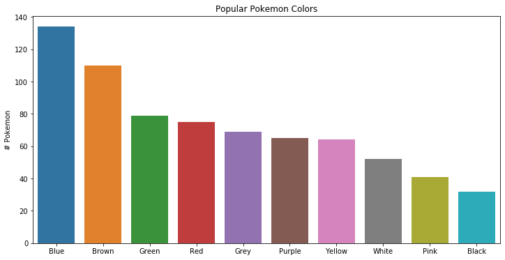

```python
fig,ax=plt.subplots(figsize=(12,6))
counts = df['Color'].value_counts()
sns.barplot(x=counts.index, y=counts.values)
ax.set_title("Popular Pokemon Colors");
ax.set_ylabel("# Pokemon");
```

**Exercise 6.6:**

Make a bar plot of the top pokemon morphologies.

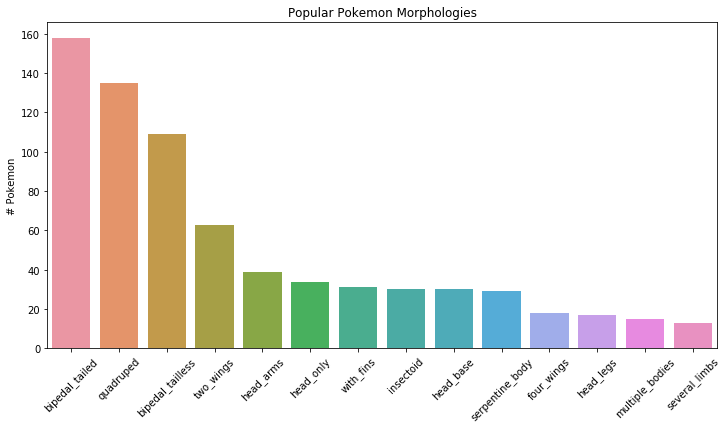

```python
fig,ax=plt.subplots(figsize=(12,6))
counts = df['Body_Style'].value_counts()
sns.barplot(x=counts.index, y=counts.values)
ax.set_title("Popular Pokemon Morphologies");
ax.set_ylabel("# Pokemon");
# Bonus - rotate the labels to make them legible
ax.tick_params(axis='x', labelrotation=45)
```

## Violin plot

For one more taste of the Seaborn capabilities, let's show a `violinplot`, to visualize the distribution of a quantitative variable, weight, across different categories specified by a second variable (in this case color). We use the keyword argument `cut=0` to cut the smoothed distribution, preventing it from extending to negative weights.

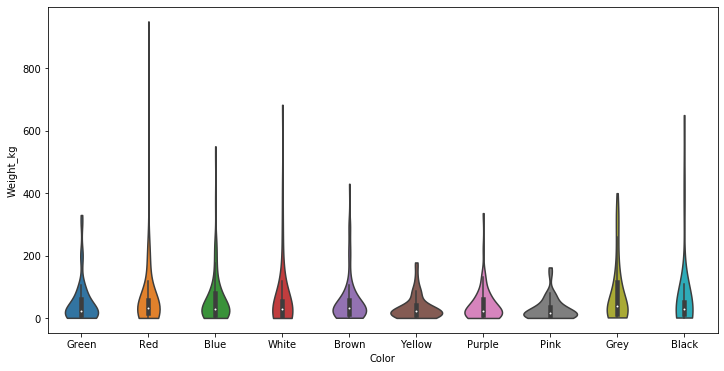

```python
fig,ax=plt.subplots(figsize=(12,6))
sns.violinplot(data=df, x='Color', y='Weight_kg', cut=0)
```

## Groupby operations

```python
grouped = df.groupby(['Body_Style','hasGender',]).mean()

columns_to_display = ['Total','Attack','Defense']

grouped[columns_to_display].head(20)
```

| Body_Style | hasGender | Total | Attack | Defense |
| --- | --- | --- | --- | --- |
| bipedal_tailed | False | 634.444444 | 118.333333 | 105.000000 |
|  | True | 424.167785 | 80.496644 | 67.684564 |
| bipedal_tailless | False | 571.142857 | 101.428571 | 100.142857 |
|  | True | 405.894737 | 74.494737 | 64.631579 |
| four_wings | True | 439.611111 | 76.777778 | 63.111111 |
| head_arms | False | 466.111111 | 71.000000 | 95.666667 |
|  | True | 421.566667 | 69.300000 | 67.866667 |
| head_base | False | 349.000000 | 66.250000 | 66.250000 |
|  | True | 397.500000 | 62.692308 | 78.730769 |
| head_legs | False | 455.000000 | 70.000000 | 80.000000 |
|  | True | 328.733333 | 60.866667 | 64.066667 |
| head_only | False | 421.727273 | 57.636364 | 69.909091 |
|  | True | 348.260870 | 57.043478 | 76.130435 |
| insectoid | True | 353.033333 | 70.966667 | 76.466667 |
| multiple_bodies | False | 465.000000 | 86.000000 | 101.000000 |
|  | True | 405.300000 | 69.200000 | 89.900000 |
| quadruped | False | 611.666667 | 103.083333 | 100.916667 |
|  | True | 400.601626 | 74.934959 | 66.349593 |
| serpentine_body | False | 653.333333 | 123.333333 | 103.666667 |
|  | True | 396.692308 | 66.884615 | 76.461538 |

**Exercise 6.7:**

Use groupby to compute mean attack points for each color of pokemon.

```python
df.groupby('Color')['Attack'].mean()
```

```
Color
Black     77.000000
Blue      75.746269
Brown     78.554545
Green     74.455696
Grey      81.971014
Pink      54.609756
Purple    71.738462
Red       82.800000
White     69.442308
Yellow    71.390625
Name: Attack, dtype: float64
```

## Making a DataFrame from scratch

**From an array**

```python
data = np.random.rand(100,3)
columns = ['feature_1','feature_2','feature_3']
df_arr = pd.DataFrame(data,columns=columns)
df_arr.head()
```

|  | feature_1 | feature_2 | feature_3 |
| --- | --- | --- | --- |
| 0 | 0.723982 | 0.857172 | 0.008379 |
| 1 | 0.822734 | 0.409382 | 0.800680 |
| 2 | 0.287303 | 0.128357 | 0.722003 |
| 3 | 0.645525 | 0.545644 | 0.430567 |
| 4 | 0.667059 | 0.815592 | 0.969207 |

**From a dictionary of lists**

```python
name = ['Larry','Moe','Curly']
score = [1.,3.2,39.]

dict_of_lists = {
    'name': name,
    'score': score,
}

df_from_dict = pd.DataFrame(dict_of_lists)
df_from_dict
```

|  | name | score |
| --- | --- | --- |
| 0 | Larry | 1.0 |
| 1 | Moe | 3.2 |
| 2 | Curly | 39.0 |

**From a list of dictionaries**

```python
list_of_dicts = [
    {'name': 'Larry', 'score': 1.0},
    {'name': 'Moe', 'score': 3.2},
    {'name': 'Curly'},
]

df_from_list = pd.DataFrame(list_of_dicts)
df_from_list
```

|  | name | score |
| --- | --- | --- |
| 0 | Larry | 1.0 |
| 1 | Moe | 3.2 |
| 2 | Curly | NaN |

## Saving (to_csv(), to_excel())

```python
save_methods = [x for x in dir(df) if 'to_' in x]
print("save_methods:")
for method in save_methods:
    print(method)
```

```
save_methods:
_to_dict_of_blocks
to_clipboard
to_csv
to_dense
to_dict
to_excel
to_feather
to_gbq
to_hdf
to_html
to_json
to_latex
to_msgpack
to_numpy
to_panel
to_parquet
to_period
to_pickle
to_records
to_sparse
to_sql
to_stata
to_string
to_timestamp
to_xarray
```

Save to Excel

```python
df_arr.to_excel('random_df.xls')
```

Save to a csv

```python
df_arr.to_csv('random_df.csv')
```

**Exercise 6.8:**

Some pokemon show a skew in their gender distribution, designated in the column `Pr_Male`. Is there a relationship between the color and gender tendencies?

```python
df.groupby('Color')['Pr_Male'].mean()
```

```
Color
Black     0.541667
Blue      0.597107
Brown     0.539663
Green     0.610714
Grey      0.553879
Pink      0.375000
Purple    0.523305
Red       0.603846
White     0.502660
Yellow    0.551339
Name: Pr_Male, dtype: float64
```

**Exercise 6.9:**

The `Catch_Rate` column indicates the prevalence of different kinds of pokemon in the population, with pokemon with larger values getting caught more frequently. Use the pandas documentation or Stack Overflow to figure how to sort a dataframe by values in this column to see the most common pokemon.

```python
df.sort_values('Catch_Rate',ascending=False).head()
```

| Name | Number | Type_1 | Type_2 | Total | HP | Attack | Defense | Sp_Atk | Sp_Def | Speed | ... | Color | hasGender | Pr_Male | Egg_Group_1 | Egg_Group_2 | hasMegaEvolution | Height_m | Weight_kg | Catch_Rate | Body_Style |
| --- | --- | --- | --- | --- | --- | --- | --- | --- | --- | --- | --- | --- | --- | --- | --- | --- | --- | --- | --- | --- | --- |
| Purrloin | 509 | Dark | NaN | 281 | 41 | 50 | 37 | 50 | 37 | 66 | ... | Purple | True | 0.50 | Field | NaN | False | 0.41 | 10.1 | 255 | quadruped |
| Minccino | 572 | Normal | NaN | 300 | 55 | 50 | 40 | 40 | 40 | 75 | ... | Grey | True | 0.25 | Field | NaN | False | 0.41 | 5.8 | 255 | quadruped |
| Bellsprout | 69 | Grass | Poison | 300 | 50 | 75 | 35 | 70 | 30 | 40 | ... | Green | True | 0.50 | Grass | NaN | False | 0.71 | 4.0 | 255 | bipedal_tailless |
| Numel | 322 | Fire | Ground | 305 | 60 | 60 | 40 | 65 | 45 | 35 | ... | Yellow | True | 0.50 | Field | NaN | False | 0.71 | 24.0 | 255 | quadruped |
| Spoink | 325 | Psychic | NaN | 330 | 60 | 25 | 35 | 70 | 80 | 60 | ... | Black | True | 0.50 | Field | NaN | False | 0.71 | 30.6 | 255 | head_arms |

5 rows × 22 columns

**Exercise 6.10:**

Explore the relationship between rarity and a skill of your choice.

Choose one skill ('Attack','Defense' or 'Speed') and do the following.

1. Use the scipy package to assess whether Catch_Rate predicts the skill.
2. Create a scatterplot to visualize how the skill depends upon the rarity of the pokemon.
3. Overlay a best fit line onto the scatterplot.

```
R = -0.41 & p = 1.09e-30
```

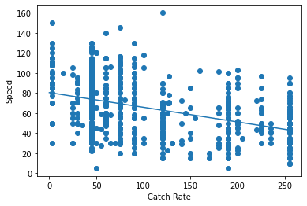

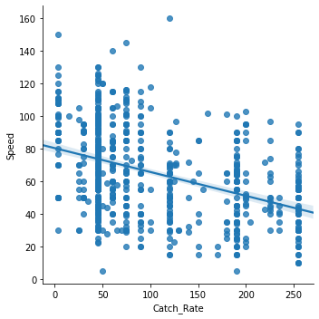

```python
from scipy.stats import linregress

slope, intercept, r_value, p_value, std_err = linregress(df['Catch_Rate'],df['Speed'],)

print('R = {:0.2f} & p = {:0.2e}'.format(r_value,p_value))

plt.scatter(df['Catch_Rate'],df['Speed'],)
plt.xlabel('Catch Rate')
plt.ylabel('Speed')

x = np.arange(256)
y = slope * x + intercept

plt.plot(x,y)

# OR

import seaborn as sns
sns.lmplot('Catch_Rate','Speed',data=df)
```

**Exercise 6.11**:

Explore the pokemon data some more and find something interesting!!

- Are pink pokemon faster/stronger/bigger than others?
- Are there tradeoffs in skills
- What kind of gender stereotypes exist in Pokemon?